# Euromart1_EDA

#### **13.What is the overall trend in sales and profit over the years?**

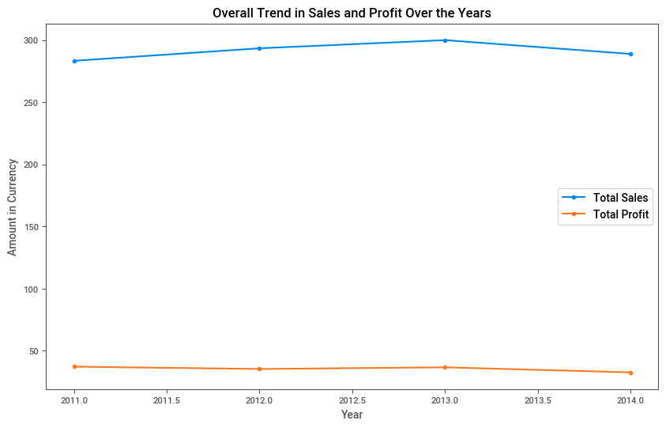

```python
# Group data by 'Year' and calculate total sales and profit for each year
yearly_data = df.groupby('Year').agg({'Sales': 'mean', 'Profit': 'mean'}).reset_index()
# Plotting the trends
plt.figure(figsize=(10, 6))
plt.plot(yearly_data['Year'], yearly_data['Sales'], label='Total Sales', marker='o')
plt.plot(yearly_data['Year'], yearly_data['Profit'], label='Total Profit', marker='o')

# Adding labels and title
plt.xlabel('Year')
plt.ylabel('Amount in Currency')
plt.title('Overall Trend in Sales and Profit Over the Years')
plt.legend()

# Show the plot
plt.show()
```

#### **14.What are the top 5 best-selling products in terms of quantity?**

```python
# Group data by 'Product Name' and calculate total quantity sold for each product
product_quantity = df.groupby('Product Name')['Quantity'].sum().reset_index()

# Sort the data by total quantity in descending order
product_quantity_sorted = product_quantity.sort_values(by='Quantity', ascending=False)

# Get the top 5 best-selling products
top_5_products = product_quantity_sorted.head(5)

# Display the top 5 best-selling products
top_5_products
```

|  | Product Name | Quantity |
| --- | --- | --- |
| 1367 | Rogers File Cart, Single Width | 108 |
| 582 | Eldon File Cart, Single Width | 104 |
| 293 | Binney & Smith Sketch Pad, Blue | 90 |
| 1645 | Stanley Pencil Sharpener, Water Color | 89 |
| 183 | Avery Index Tab, Clear | 81 |

- Top Selling Products: The top-selling products based on quantity sold are the "Rogers File Cart, Single Width" and the "Eldon File Cart, Single Width," indicating high demand for file carts.
- Popular Stationery: Stationery items such as the "Binney & Smith Sketch Pad, Blue" and the "Stanley Pencil Sharpener, Water Color" also show considerable sales quantities, suggesting a demand for office supplies.
- Index Tab Sales: The "Avery Index Tab, Clear" also has notable sales, indicating a need for organizational accessories.